# final_Project4_data_1

- 1. Introduction
- 2. preliminary process of Data
  - 2.1 Load libraries
  - 2.2 Read the Data
- 3. Data preparation
  - 3.1 Check for missing data
- 4. Question 1
  - 4.1 feature selection ?
- 5. Question 2
  - 5.1 plot 1 : PARALLEL PLOT
  - 5.2 plot 2 : Distplot
  - 5.3 plot 3 : Scatter plot + size + color
  - 5.4 plot 4 : Scatter and Line plots
- 6. Question 3
  - 6.1 plot 5 : scatter plot Map
  - 6.2 plot 6 : Filter and Aggregate

# 1. Intoduction

# 2. preliminary process of Data

### 2.1 Load libraries

We import pandas to work with our data, Matplotlib to plot charts, and Seaborn to make our charts prettier.

```python
import numpy as np
import pandas as pd
import matplotlib.pyplot as plt
import seaborn as sns
import plotly.offline as py
import plotly.graph_objs as go
color = sns.color_palette()
sns.set(style="darkgrid")
from sklearn.preprocessing import StandardScaler, LabelEncoder, OneHotEncoder, MinMaxScaler
```

### 2.2 Read the Data

Let's load the GlobalCitiesPBI.csv which has been provided in datasets for the course.

```python
rawdf = pd.read_csv('GlobalCitiesPBI.csv')
rawdf.head()
```

|  | Geography | Continent | Country | City.Area..km2. | Metro.Area..km2. | City.Population..millions. | Metro.Population..millions. | Annual.Population.Growth | GDP.Per.Capita..thousands....PPP.rates..per.resident. | Primary.Industry | ... | Number.of.Museums | Air.Quality. | Laws.or.Regulations.to.Improve.Energy.Efficiency | rating | gen.rating | Life.Expectancy | Laws.or.Regulations.to.Improve.Energy.Efficiency.Flag | Anti.Smoking.Legislation.Flag | Sort_gen.rating | Sort_rating |
| --- | --- | --- | --- | --- | --- | --- | --- | --- | --- | --- | --- | --- | --- | --- | --- | --- | --- | --- | --- | --- | --- |
| 0 | Amsterdam | Europe | The Netherlands | 165.00 | 807.00 | 0.76 | 1.40 | 0.01 | 46.0 | Research and Advising | ... | 68 | 24 | Yes | Alpha- | Alpha | 79 | 1 | 1 | 1 | 4 |
| 1 | Ankara | Europe | Turkey | 30.72 | 25437.00 | 3.54 | 4.77 | 0.26 | 21.2 | Wholesale and Retail Trade | ... | 36 | 46 | No | Gamma | Gamma | 78 | 0 | 1 | 3 | 9 |
| 2 | Athens | Europe | Greece | 38.91 | 380.69 | 0.66 | 4.01 | 0.00 | 30.5 | Finance & Corporate Services | ... | 47 | 41 | Yes | Beta+ | Beta | 81 | 1 | 1 | 2 | 5 |
| 3 | Bangkok | Asia | Thailand | 1569.00 | 7762.00 | 5.72 | 6.50 | 0.03 | 23.4 | Agriculture | ... | 27 | 54 | Yes | Alpha | Alpha | 72 | 1 | 1 | 1 | 3 |
| 4 | Barcelona | Europe | Spain | 102.60 | 3236.00 | 1.62 | 3.23 | 0.01 | 36.3 | Services | ... | 69 | 35 | Yes | Alpha- | Alpha | 82 | 1 | 1 | 1 | 4 |

5 rows × 32 columns

# 3. Data preparation

### 3.1 Check for missing data

```python
# checking missing data
total = rawdf.isnull().sum().sort_values(ascending = False)
percent = (rawdf.isnull().sum()/rawdf.isnull().count()).sort_values(ascending = False)
missing_data  = pd.concat([total, percent], axis=1, keys=['Total missing ', 'Percent'])
missing_data
```

|  | Total missing | Percent |
| --- | --- | --- |
| Sort_rating | 0 | 0.0 |
| Sort_gen.rating | 0 | 0.0 |
| Continent | 0 | 0.0 |
| Country | 0 | 0.0 |
| City.Area..km2. | 0 | 0.0 |
| Metro.Area..km2. | 0 | 0.0 |
| City.Population..millions. | 0 | 0.0 |
| Metro.Population..millions. | 0 | 0.0 |
| Annual.Population.Growth | 0 | 0.0 |
| GDP.Per.Capita..thousands....PPP.rates..per.resident. | 0 | 0.0 |
| Primary.Industry | 0 | 0.0 |
| Secondary.Industry | 0 | 0.0 |
| Unemployment.Rate | 0 | 0.0 |
| Poverty.Rate | 0 | 0.0 |
| Public.Transportation | 0 | 0.0 |
| Major.Airports | 0 | 0.0 |
| Major.Ports | 0 | 0.0 |
| Higher.Education.Institutions | 0 | 0.0 |
| Infant.Mortality..Deaths.per.1.000.Births. | 0 | 0.0 |
| Life.Expectancy.in.Years..Male. | 0 | 0.0 |
| Life.Expectancy.in.Years..Female. | 0 | 0.0 |
| Number.of.Hospitals | 0 | 0.0 |
| Anti.Smoking.Legislation | 0 | 0.0 |
| Number.of.Museums | 0 | 0.0 |
| Air.Quality. | 0 | 0.0 |
| Laws.or.Regulations.to.Improve.Energy.Efficiency | 0 | 0.0 |
| rating | 0 | 0.0 |
| gen.rating | 0 | 0.0 |
| Life.Expectancy | 0 | 0.0 |
| Laws.or.Regulations.to.Improve.Energy.Efficiency.Flag | 0 | 0.0 |
| Anti.Smoking.Legislation.Flag | 0 | 0.0 |
| Geography | 0 | 0.0 |

# 4. Question 1

we need to choose a list of variables (at most 7) that are crucial to a good understanding of the dataset:

### 4.1 Feature selection

#### 4.1.1 Selecting highly correlated features

The relevant features here is done using correlation matrix, we will select the 5-top features with high correlation.

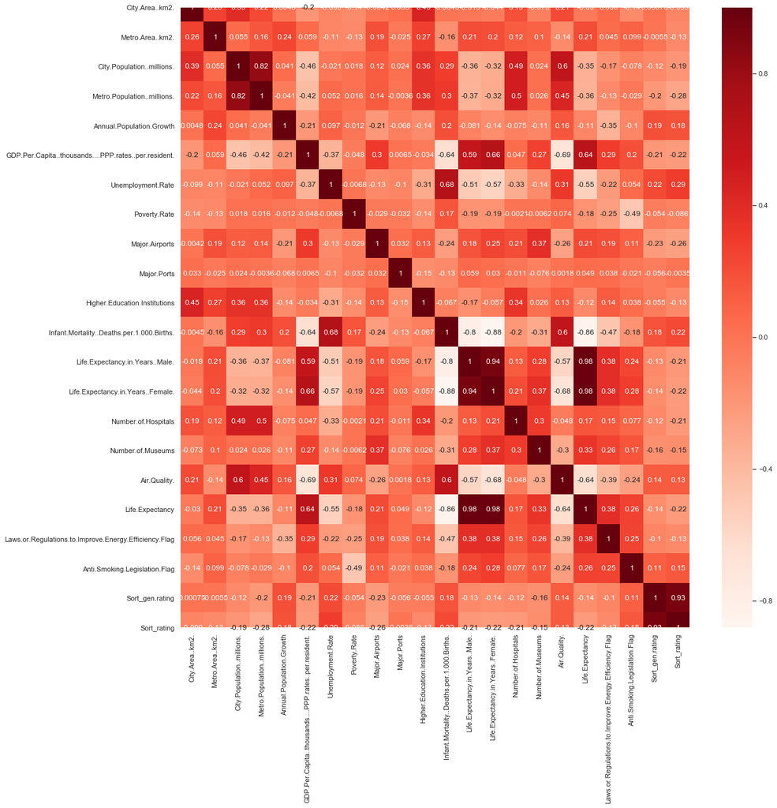

```python
plt.figure(figsize=(18,18))

cor = rawdf.corr()
sns.heatmap(cor, annot=True, cmap=plt.cm.Reds)
plt.show()
```

```python
#Correlation with output variable
cor_target = abs(cor["Sort_rating"])
a = cor_target.sort_values(ascending=False)[1:6]
print('the 5-top features with high correlation are : \n \n {} '.format(a))
```

```
the 5-top features with high correlation are :

 Sort_gen.rating                                          0.928122
Unemployment.Rate                                        0.292510
Metro.Population..millions.                              0.279936
Major.Airports                                           0.256257
GDP.Per.Capita..thousands....PPP.rates..per.resident.    0.223249
Name: Sort_rating, dtype: float64
```

# 5. Question 2

In this question we gonna create 4 multivariate visualizations for the dataset using the variables listed in question 1.

### 5.1 plot 1 : PARALLEL PLOT

```python
import plotly.express as px

data = rawdf[["Geography","Unemployment.Rate","Metro.Population..millions.","Major.Airports","GDP.Per.Capita..thousands....PPP.rates..per.resident.","Infant.Mortality..Deaths.per.1.000.Births.","Sort_gen.rating","Life.Expectancy.in.Years..Female.","Life.Expectancy.in.Years..Male."]]

plt.figure(figsize=(20,15))
fig = px.parallel_coordinates(data, color="Sort_gen.rating",
                              labels={"Sort_gen.rating": "gen rating",
                                      "Geography" : "Geography",
                                       "Major.Airports": "Major airoport",
                                        "Metro.Population..millions.": "Metro population",
                                        "Infant.Mortality..Deaths.per.1.000.Births.": "infant mortaliy deaths",
                                        "GDP.Per.Capita..thousands....PPP.rates..per.resident.": "GDP",
                                         "Unemployment.Rate" : "Unemployment Rate",
                                      "Life.Expectancy.in.Years..Female." : "Life Expectancy Female.",
                                       "Life.Expectancy.in.Years..Male." : "Life Expectancy Male."
                                      },
                              color_continuous_scale=px.colors.diverging.Tealrose,
                              color_continuous_midpoint=2
                              )





fig.show()
```

[interactive chart not shown]

**Notes:**

1. This parallel coordinates plot allows to compare the feature of several individual observations.
2. It allows to study the features of samples for several quantitative variables. Its strength is that the variables can even be completely different: different ranges and even different units.
3. In the graphic above the Cities were grouped by the gen_rating and from that plot we can easily detect/visualise that there is only onne city on the groupe with gen_rating = 4 (Sufficiency) and this city is : Jerusalem.

### 5.2 plot 2 : Distplot

```python
import plotly.figure_factory as ff
import numpy as np

#df =  pd.read_csv('GlobalCitiesPBI.csv')
df = data
# Add histogram data
x1 = df['Life.Expectancy.in.Years..Female.']
x2 = df['Life.Expectancy.in.Years..Male.']


# Group data together
hist_data = [x1, x2]

group_labels = ['Life Expectancy Female', 'Life Expectancy Male']

# Create distplot with custom bin_size
fig = ff.create_distplot(hist_data, group_labels)
fig.show()
```

[interactive chart not shown]

**Notes:**

1. This distplot figure displays a combination of statistical representations of numerical data, such as histogram, kernel density estimation in the same figure.
2. From this plot we can say that : in average Life Expectancy for Male is less than Life Expectancy for Female.

### 5.3 plot 3 : Scatter plot + size + color

```python
import plotly.express as px
px.scatter(data, x='GDP.Per.Capita..thousands....PPP.rates..per.resident.', y='Infant.Mortality..Deaths.per.1.000.Births.',
           size='Metro.Population..millions.', color='Geography', width=900, height=400,
           title = "relationship between GDP and infant mortality deaths with Metro Population as size of the bubbles")
```

[interactive chart not shown]

**Notes:**

1. Here we illustrate The relationship between **GDP** and **infant mortality deaths** for different Cities.
2. the Metro populations does not depend on the GPD and infant mortality deaths rate.
3. The infant mortality rate indicates how many babies die in their first year of life, and this feature is obviously depend on GDP index, and we can can see from this plot the pattern bettween GDP and infant mortality deaths (the less GDP the more rate of infant mortality rate).

### 5.4 plot 4 : Scatter and Line plots

```python
import plotly.express as px

df = pd.read_csv('GlobalCitiesPBI.csv')

df['text'] = df['Geography']

fig = px.scatter(df, x="Metro.Population..millions.", y="Infant.Mortality..Deaths.per.1.000.Births.",  color="gen.rating", marginal_y="violin",
           marginal_x="box", trendline="ols")
fig.show()
```

[interactive chart not shown]

**Notes:**

1. This Scatter plots are similar to line graphs in which we are mapping Metro population vs infant mortality rate grouped by gen_rating.

# 6. Question 3

Question 3 : “definitive” visualizations for the dataset.

### 6.1 plot 5 : scatter plot Map

#### Looking for the "latitude" and "longitude" associeted to Our Cities.

```python
!pip install opencage
```

```python
data = pd.read_csv('GlobalCitiesPBI.csv')

from opencage.geocoder import OpenCageGeocode

key = 'de4f24290886448da691eb368c1cb52b'
geocoder = OpenCageGeocode(key)
list_lat = []   # create empty lists
list_long = []
for index, row in data.iterrows(): # iterate over rows in dataframe
    City = row['Geography']
    query = str(City)
    results = geocoder.geocode(query)
    lat = results[0]['geometry']['lat']
    long = results[0]['geometry']['lng']
    print(query,lat,long)
    list_lat.append(lat)
    list_long.append(long)
# create new columns from lists

data['lat'] = list_lat
data['lon'] = list_long
data.head()

#from google.colab import files
#data.to_csv('data.csv')
```

```
Amsterdam 52.3745403 4.8979755
Ankara 39.9207774 32.854067
Athens 33.9597677 -83.376398
Bangkok 13.7244327 100.6033853
Barcelona 41.3828939 2.1774322
Beijing 39.906217 116.3912757
Berlin 52.5170365 13.3888599
Bogota 4.59808 -74.0760439
Boston 42.3602534 -71.0582912
Brussels 50.8465573 4.351697
Buenos Aires -34.6075682 -58.4370894
Cairo 30.048819 31.243666
Chicago 41.8755616 -87.6244212
Cologne 50.938361 6.959974
Copenhagen 55.6867243 12.5700724
Delhi 28.6517178 77.2219388
Dhaka 23.7593572 90.3788136
Dubai 25.0750095 55.1887609
Dublin 53.3497645 -6.2602732
Frankfurt 50.1106444 8.6820917
Geneva 46.2017559 6.1466014
Guangzhou 23.1301964 113.2592945
Hamburg 53.550341 10.000654
Hanoi 21.0294498 105.8544441
Helsinki 60.1674098 24.9425769
Ho Chi Minh City 10.6497452 106.7619794
Hong Kong 22.350627 114.1849161
Houston 29.7589382 -95.3676974
Istanbul 41.0096334 28.9651646
Jakarta -6.1753942 106.827183
Jerusalem 31.778345 35.2250786
Johannesburg -26.205 28.049722
Karachi 25.1446897 67.1847767
Kolkata 22.5677459 88.3476023
Lagos 20.0171109 103.378253
Lima -12.0621065 -77.0365256
Lisbon 38.7077507 -9.1365919
Los Angeles 34.0536909 -118.2427666
Madrid 40.4167047 -3.7035825
Manila 14.5906216 120.9799696
```

[output cut: 13 more lines]

```
Sao Paulo -23.5506507 -46.6333824
Seoul 37.5666791 126.9782914
Shanghai 31.2252985 121.4890497
Shenzhen 22.5445697 114.0545346
Singapore 1.340863 103.8303918
St. Petersburg 59.938732 30.316229
Stockholm 59.3251172 18.0710935
Sydney -33.8548157 151.2164539
Taipei 25.0375198 121.5636796
Tokyo 35.6828387 139.7594549
Toronto 43.653963 -79.387207
Vancouver 49.2608724 -123.1139529
Vienna 48.2083537 16.3725042
Warsaw 52.2319237 21.0067265
Zurich 47.3723941 8.5423328
```

|  | Geography | Continent | Country | City.Area..km2. | Metro.Area..km2. | City.Population..millions. | Metro.Population..millions. | Annual.Population.Growth | GDP.Per.Capita..thousands....PPP.rates..per.resident. | Primary.Industry | ... | Laws.or.Regulations.to.Improve.Energy.Efficiency | rating | gen.rating | Life.Expectancy | Laws.or.Regulations.to.Improve.Energy.Efficiency.Flag | Anti.Smoking.Legislation.Flag | Sort_gen.rating | Sort_rating | lat | lon |
| --- | --- | --- | --- | --- | --- | --- | --- | --- | --- | --- | --- | --- | --- | --- | --- | --- | --- | --- | --- | --- | --- |
| 0 | Amsterdam | Europe | The Netherlands | 165.00 | 807.00 | 0.76 | 1.40 | 0.01 | 46.0 | Research and Advising | ... | Yes | Alpha- | Alpha | 79 | 1 | 1 | 1 | 4 | 52.374540 | 4.897976 |
| 1 | Ankara | Europe | Turkey | 30.72 | 25437.00 | 3.54 | 4.77 | 0.26 | 21.2 | Wholesale and Retail Trade | ... | No | Gamma | Gamma | 78 | 0 | 1 | 3 | 9 | 39.920777 | 32.854067 |
| 2 | Athens | Europe | Greece | 38.91 | 380.69 | 0.66 | 4.01 | 0.00 | 30.5 | Finance & Corporate Services | ... | Yes | Beta+ | Beta | 81 | 1 | 1 | 2 | 5 | 33.959768 | -83.376398 |
| 3 | Bangkok | Asia | Thailand | 1569.00 | 7762.00 | 5.72 | 6.50 | 0.03 | 23.4 | Agriculture | ... | Yes | Alpha | Alpha | 72 | 1 | 1 | 1 | 3 | 13.724433 | 100.603385 |
| 4 | Barcelona | Europe | Spain | 102.60 | 3236.00 | 1.62 | 3.23 | 0.01 | 36.3 | Services | ... | Yes | Alpha- | Alpha | 82 | 1 | 1 | 1 | 4 | 41.382894 | 2.177432 |

5 rows × 34 columns

#### Using Scattergeo

```python
import plotly.graph_objects as go

data['text'] = 'City: ' + data['Geography'] + ', ' + 'groupe rating:' + data['Sort_gen.rating'].astype(str) + ', ' + 'GDP:' + data['GDP.Per.Capita..thousands....PPP.rates..per.resident.'].astype(str)


# Add scattergeo globe map of volcano locations
fig = go.Figure(data= go.Scattergeo(
              lat=data["lat"],
              lon=data["lon"],
              mode="markers",
              hoverinfo="text",
              showlegend=False,
              marker=dict(color="crimson", size=4, opacity=0.8)))



fig = go.Figure(data=go.Scattergeo(
        lat=data["lat"],
        lon=data["lon"],
        text = data['text'],
        mode = 'markers',
        marker = dict(
            #size = 8,
            size = data["Sort_gen.rating"]*10,
            opacity = 0.8,
            reversescale = True,
            autocolorscale = True,
            symbol = 'circle',
            line = dict(
                width=1,
                color='rgba(102, 102, 102)'
            ),
            colorscale = 'Blues',
            cmin = 0,
            color = data['GDP.Per.Capita..thousands....PPP.rates..per.resident.'],
            cmax = data['GDP.Per.Capita..thousands....PPP.rates..per.resident.'].max(),
            colorbar_title="GDP"
        )))


fig.update_layout(
        title = 'GDP Scatter maps plot with gen.rating as size of the bubbles',
        geo = dict(
            projection_type='natural earth',
            showland = True,
            landcolor = "rgb(250, 250, 250)",
            subunitcolor = "rgb(217, 217, 217)",
            countrycolor = "rgb(217, 217, 217)",
            countrywidth = 0.5,
            subunitwidth = 0.5
        ),
    )
fig.show()
```

[interactive chart not shown]

**Notes:**

1. we notice that san Francisco, Los Angeles, New York,Houston, Boston situated in North America are characterized by high GDP index.
2. Jerusalem is the city that have less connections with the world (the gen.rating = 4 (Sufficiency)).

### 6.2 plot 6 : Filter and Aggregate

```python
import plotly.io as pio
import pandas as pd

df =  pd.read_csv('GlobalCitiesPBI.csv')


colors = ['red','blue', 'orange', 'green']

opt = []
opts = []
for i in range(0, len(colors)):
    opt = dict(
        target = df['gen.rating'][[i]].unique(), value = dict(marker = dict(color = colors[i]))
    )
    opts.append(opt)

data = [dict(
  type = 'scatter',
  mode = 'markers',
  x = df['Life.Expectancy'],
  y = df['GDP.Per.Capita..thousands....PPP.rates..per.resident.'],
  text = df['gen.rating'],
  hoverinfo = 'text',
  opacity = 0.8,
  marker = dict(
      size = df['Major.Airports']*3,
  ),
  transforms = [
      dict(
        type = 'groupby',
        groups = df['gen.rating'],
        styles = opts
      ),
      dict(
        type = 'aggregate',
        groups = df['gen.rating'],
        aggregations = [
            dict(target = 'x', func = 'avg'),
            dict(target = 'y', func = 'avg'),
            dict(target = 'marker.size', func = 'sum')
        ]
      )]
)]

layout = dict(
    title = '<b>Gapminder</b><br> Average GDP Per Cap & Life Exp by gen_gating',
)

fig_dict = dict(data=data, layout=layout)
pio.show(fig_dict, validate=False)
```

[interactive chart not shown]